# 2: ENERGY

###### Nothing exists without energy. Everything exists within the laws of energy.

##### **Synopsis:** Nothing exists without energy, as everything is an expression of energy. This includes thoughts, archetypes, ideas, concepts, and all manifest forms. Energy creates patterns, which in turn create archetypes, which in turn create form. Form and archetype are instances of the same expression in different contexts. Our understanding of energy (and all things) is limited by our ability to perceive and understand.

##### **Keywords:** energy, archetypes, reality, material

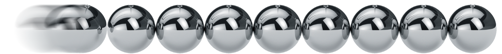

We will examine energy repeatedly throughout this work, but at this stage, we need only distinguish two fundamental types. *Kinetic energy* represents energy capable of causing change to a system through movement, such as water passing through a turbine in a dam. *Potential energy* represents energy that is not currently moving but remains available, such as all the water in the dam not yet passing through the turbine. The important point here is that potential will always move given the chance; that is, potential energy is energy that “wants” to move but can’t under its current context.

Science, mythology, and religion each offer their own narratives and theories. Not surprisingly, many of these theories are not conceptually distant from each other. If we accept the first law of thermodynamics, which states that energy cannot be destroyed or created, then the energy that generated this Universe must have existed before the Universe was created. Where this primal energy originated remains unanswered, and likely will remain so, at least by modern science. Still, prior to the kinetic energy of the Big Bang, there must have been the potential energy of the Big Bang, which was energy that “wanted” to move.

For our purposes at this moment, the details of these theories or stories do not matter. What matters is the general principle. Once energy entered the chaos of the void, something happened. That “something” was some form of movement, as movement defines the undeniable nature of energy. Energy moves only as a function of balancing an imbalance, i.e., “balancing” as a verb (active transformation). Once that balance is achieved, the function of energy is to maintain that state of balance, i.e., “balanced” as a noun (passive persistence). Although it is a bit anthropomorphic, we can say that the purpose of energy is to create and maintain balance. This energy operates according to certain laws and within the context of duality. This duality can manifest as somethingness/nothingness, 1/0, any polarity, or any difference between two things that can potentially interact.

#### **Key 5:** Everything exists in a state of duality.

This raises a profound question. Did these laws exist before creation? Did they exist in the chaotic primal void of nothingness or in the state of the potential energy that had yet to “move”? The reasonable answer is both yes and no. “No,” they did not exist in the primal void because these laws only apply where time and space exist, neither of which existed prior to the introduction of energy. “Yes,” in that these laws must have existed “in theory.” For example, the relation between a circle’s circumference and its radius existed as the constant π (pi), and the relationship between a circle and a square involved an infinite regression, but, as there were no circles or squares, these relationships were not measurable. There was no *instance* of π, but there was, for lack of a better word, an *archetype* of those relationships. In this context, we use the traditional and current definition of the word *archetype* as per the Oxford English Dictionary.

> The most typical or perfect example of a particular kind of person or thing

The only place where the potential for anything to exist, including concepts, ideas, or archetypes, is where something *can* exist, a place where somethingness *coexists* with nothingness. Zero can exist, and infinity can exist, but unless they commingle, there will never be numbers (or anything else). When they do mix, numbers appear, and with them, these archetypal laws such as πr² and 1+1=2 become instantiated in reality. “But!” you may be thinking, “If archetypes can only exist in a duality, and there was no duality before *somethingness* appeared in *nothingness*, how could the archetypes have existed?” They could not, suggesting a preexisting duality from which our current reality emerged, in which these archetypes and laws already existed. Perhaps that preexisting duality resembles a “sea” of infinite “waves” of uninstantiated possibilities destined to forever crash upon the shores of matter? This poetic description also applies to what quantum mechanics calls *wave functions* that represent all potential instances. Until one of those waves *collapses* into a material form, it remains in the duality of lonely archetypes.

In quantum physics, waves with higher probabilities are more likely to reach the shores of form (though even low-probability events can and do occur, just less frequently). The profound insight here is not simply that what is most likely to happen will probably happen, but that reality functions as a multidimensional cosmic casino. We do not know where an electron exists. We only know the probability of where we might find an electron. The probability field of an electron in your finger stretches to the end of the Universe, but the odds of finding one of your finger’s electrons on Zeta Reticuli 39.3 light-years away is as likely as hitting the winning number on a roulette wheel with 10<sup>82</sup> numbers (pointless fun fact: that would be roulette wheel 10<sup>76</sup> light-years wide in diameter which would take 3 × 10<sup>76</sup> years to spin just once if it was spinning at the speed of light). Your finger’s electron is likely to be found where it is right now, in your finger, but there’s a *chance* it *could* appear on Zeta Reticuli, and for all you know, some of your electrons are there right now! Yet even that is not the most remarkable aspect. If an electron is actually a wave described by a potential field, and that field extends to the end of the Universe, then that electron field is as large as the Universe itself, that is, until it collapses into a femtometer-sized dot (that’s 10<sup>-15</sup> of a meter, or 0.000000000000001 m). Every electron’s field in your body, and everything else, extends to every corner of existence, at least in the archetypal realm of laws that our reality exists within, and to the best of our ability to understand those laws.

## Modern Concept, Ancient History

Without delving too deeply into philosophy here, the idea of archetypal forms is profoundly Platonic. Plato’s *Theory of Ideas* proposes that everything that exists is a material instance of an ideal version, or perfect idea, of that thing.

It is also a Kantian idea, and a Lockean, Cartesian, and Humean idea, for all these great thinkers, plus many more, understood in one form or another that *things* were primarily *ideas* or *concepts* first. Not all philosophers and scientists of old agreed, and historically, the debate usually boiled down to some form of “is there a god?”[^1] Today, science tends to avoid the concept of a god but asks equally impossible questions, such as “is reality a hologram?” or “is existence a simulation?” This book addresses these questions, but the answer is as maddening as it is enlightening, and words like “yes” or “no” become meaningless.

Throughout most of human history, there has been an archetypal, theoretical, spiritual, or mystical concept of a realm of ideas. In this realm, forms exist in their unmanifest, uninstantiated state as pure ideas. The perfect cube, for example, is a concept we all can grasp, but whose instances in the material world can only approach perfection. These archetypal forms follow archetypal laws; if they did not, the relationship between the area of a circle and its radius could just as well be “elephant toes on Tuesday afternoon” or “cat dog moo.”

This concept that unmanifest forms are the same as ideas, existing in a non-physical, non-manifest, non-instantiated state, provides an elegant explanation for the origin and nature of the laws of physics. Just as physical forms like the ball and the cube have their ideal archetypes, the laws of physics and nature also possess their archetypal forms.

The laws of a form and the form itself are not separate things. They are the same thing expressed in two different forms. Form itself is simply the result of a function, or by-product, of the law (or laws) as it is expressed within some material context. The form *is* the instantiation of the law. A circle is defined by its law, 2πr, and what we see as a circle is an instance of this law. Archetypes can also have archetypes, which we might refer to as *meta-archetypes* or *meta-types*. For example, the *meta-type* or *meta-archetype* of a circle (2πr) is the concept of a dot, which is a 0-dimensional point.

#### **Key 6:** Theories and ideas are archetypes in their own right, but like forms, they also have their archetypes.

Laws are the blueprints of form, and forms are the instances of the blueprint. How do we know that the laws were not derived from the form, rather than the form being derived from the law? We address this question in more depth later, but the evidence suggests that the same laws exist across many forms. One specific archetype, like that of a cube or a sphere, can have many instances, but a cube or a sphere cannot have many archetypes. This places the laws of form “higher” in the unfolding process of creation, as the law must exist before the formation or instantiation of the form. This is additionally supported by the understanding that the laws themselves are an expression of energy, the ordering force behind all existence, and therefore a prerequisite to form, whether archetypal or material.

#### **Key 7:** Levels of order begin with energy, which has laws regarding how it interacts with itself, which forms patterns (archetypes), which create things (material instances).

You may be asking, “OK, but what if Plato and the others were wrong?” This is not a relevant question because that question assumes we have access to, or can grasp, the “ultimate truth,” if one even exists. Our theories of reality are predictive models based on our understanding and abilities, and they remain valid for the reality we can observe.

#### **Key 8:** All theories are only valid for a level of awareness, a level of knowledge, the context of both, and the limits of their application.

Even if Plato is “wrong,” which at some level, at some point, in some reality, must be true, if his ideas form the basis of understanding that allows us to create abstract concepts that can lead to new, testable understandings, then it is “true” until something better, or *more true*, emerges. For the record, Aristotle rejected Plato’s ideas of forms and stated that all things could only come into existence via matter. From the perspective of this book, both can be true, as one deals with the world of archetypes and ideas and the other strictly with materialism. In both cases of *form* and the *laws of form*, there is one concept that simply expresses itself relative to the context of its scope, whether ideas or matter.

Although today we tend to think of Plato’s *Theory of Ideas* as an abstraction, Plato was quite clear that this realm was as real as the realm we exist in every day. The difference is that, in the material realm, we can never know the true form or idea because of the limitations of material reality. This is the basic theme of Plato’s *Allegory of the Cave*, which describes this reality as limited since material form is no more than a mere shadow and echo of the true reality (of ideas and archetypes). Parmenides (~500 B.C.) also proposed that observable reality was a by-product of an underlying, hidden reality composed of an interconnected, invisible network of the smallest possible things that can exist, a concept later adopted by Democritus (~400 B.C.), who coined the term “atom.” These ancient ideas persist in modern theories that describe *massless matter* and suggest that matter itself can spontaneously come into existence out of nothing as a result of energy and order.

#### **Key 9:** Everything that exists is an instance of archetypes.

Archetypes of form and the laws of those archetypes are the same thing. What we call archetypes of form are the results of these laws. What we see in our reality are the instantiations of those archetypes. Before exploring the subject of energy further, we must first explore the subject of *order*, as they are inextricably bound to each other.

[^1]: This idea, and much more, is discussed at length in an 89-volume edition of great works that question the nature of existence. Glattfelder, James B. Information, **Consciousness, Reality: How a New Understanding of the Universe Can Help Answer Age-Old Questions of Existence**. Cham: Springer International Publishing, 2019. Available online at https://link.springer.com/bookseries/5342